# Python Functions

**For longer and more complex tasks, it is important to organize your code into reuseable elements.**  
For example, if you find yourself cutting and pasting the same or similar lines of code over and over, you probably need to define a function to encapsulate that code and make it reusable. An important principle in programming in DRY: “don’t repeat yourself”. Repetition is tedious and opens you up to errors. Strive for elegance and simplicity in your programs.

Functions are a central part of advanced python programming. Functions take some inputs (“arguments”) and do something in response. Usually functions return something, but not always.

## Simple functions

```python
# define a function
def say_hello():
    """Return the word hello."""
    return 'Hello'
```

```python
# functions are also objects
type(say_hello)
```

```
function
```

```python
# this doesnt call
say_hello?
```

```
Signature: say_hello()
Docstring: Return the word hello.
File:      ~/Dropbox/My Mac (ml-181129-002)/Documents/coursework/teaching/ocean-pytools/<ipython-input-1-bb61eb640ca7>
Type:      function
```

```python
# this does
say_hello()
```

```
'Hello'
```

```python
# assign the result to something
res = say_hello()
res
```

```
'Hello'
```

```python
# take some arguments
def say_hello_to(name):
    """Return a greeting to `name`"""
    return 'Hello ' + name
```

```python
# intended usage
say_hello_to('World')
```

```
'Hello World'
```

```python
say_hello_to(10)
```

```
---------------------------------------------------------------------------
TypeError                                 Traceback (most recent call last)
<ipython-input-9-aa350718f87f> in <module>
----> 1 say_hello_to(10)
      2

<ipython-input-7-53e58b3665ab> in say_hello_to(name)
      2 def say_hello_to(name):
      3     """Return a greeting to `name`"""
----> 4     return 'Hello ' + name
      5

TypeError: must be str, not int
```

```python
# redefine the function
def say_hello_to(name):
    """Return a greeting to `name`"""
    return 'Hello ' + str(name)
```

```python
say_hello_to(10)
```

```
'Hello 10'
```

```python
# take an optional keyword argument
def say_hello_or_molo(name, isiXhosa=False):
    """Say hello in multiple languages."""
    if isiXhosa:
        greeting = 'Molo '
    else:
        greeting = 'Hello '
    return greeting + name
```

```python
print(say_hello_or_molo('Sindi'))
print(say_hello_or_molo('Issi', isiXhosa=True))
```

```
Hello Sindi
Molo Issi
```

```python
# flexible number of arguments
def say_hello_to_everyone(*args):
    return ['hello ' + str(a) for a in args]
```

```python
say_hello_to_everyone('Sindi','Issi', 'Christo')
```

```
['hello Sindi', 'hello Issi', 'hello Christo']
```

## A more complex functions:

### Fibonacci Sequence

The Fibonacci sequence is the 1,1,2,3,5,8…, the sum of each number with the preceding one. Write a function to compute the Fibonacci sequence of length n. (Hint, use some list methods.)

```python
def fib(n):
    l = [1,1]
    for i in range(n-2):
        l.append(l[-1] + l[-2])
    return l
```

```python
fib(10)
```

```
[1, 1, 2, 3, 5, 8, 13, 21, 34, 55]
```

## Sinusiod Function

A sine wave is given by the function:

$$ Asin(\omega t), $$

where A = amplitude  
t = time  
$\omega$ (omega)= Frequency

```python
# this function relies on the python packages numpy and matplotlib

import numpy as np
import matplotlib.pyplot as plt
```

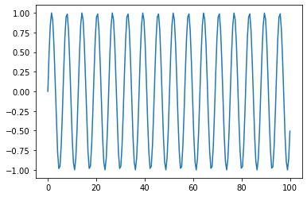

```python
# Get x values of the sine wave

time = np.linspace(0, 100, 200)

# Amplitude of the sine wave is sine of a variable like time

amplitude   = np.sin(time)


# Plot a sine wave using time and amplitude obtained for the sine wave

plt.plot(time, amplitude)
```

Now write a function where the you can change the frequency (input argument is frequency)

```python
def make_sin(frequency):
    """
    Creates a sin wave
    Inputs: Amplitude and Frequency
    Output: Plot of sine wave
    """

    time = np.linspace(0, 100, frequency)
    amplitude   = np.sin(time)

    out = plt.plot(time, amplitude)
    return out
```

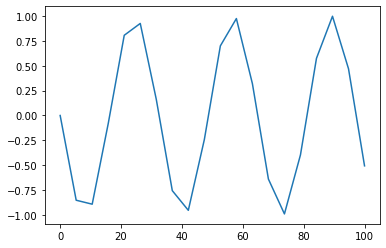

```python
make_sin(20)
```